# Ketchup is a Vegetable

Michael Sumner

28 January 2017

This is a circle.

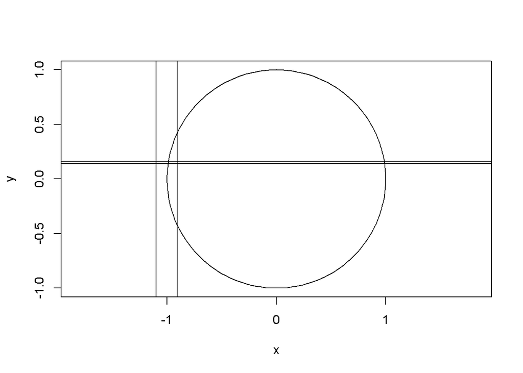

```r
circle <- function(x = 0, y = 0, rad = 1, n_vert =  180) {
  ## see plotrix::draw.circle
  inc <- 2 * pi/n_vert
  angles <- seq(0, 2 * pi - inc, by = inc)
  angles <- c(angles, angles[1L])
  xv <- cos(angles) * rad + x
  yv <- sin(angles) * rad + y
  data.frame(x = xv, y = yv)
}
plot(circle(), asp = 1, type = "l")


xl <- c(-1.1, -0.9)
yl <- c(0.14, 0.16)
abline(v = xl, h = yl)
```

No, it is not a circle.

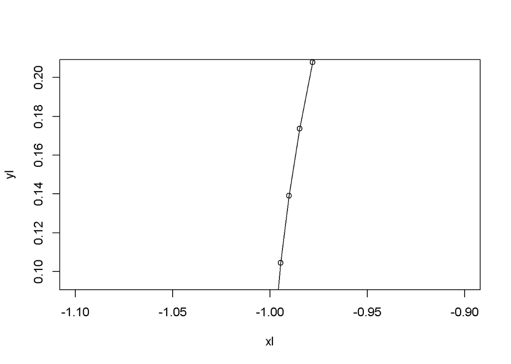

```r
plot(xl, yl, asp = 1, type = "n")
lines(circle(), asp = 1)
points(circle())
```

## Correct

Which is “correct”? Neither, it’s a circle for some purposes, but not for others. Technically, while we can change the parameters in the approximation to be “more correct” (?), we can’t ever get the mathematician’s circle without rather different code than this.

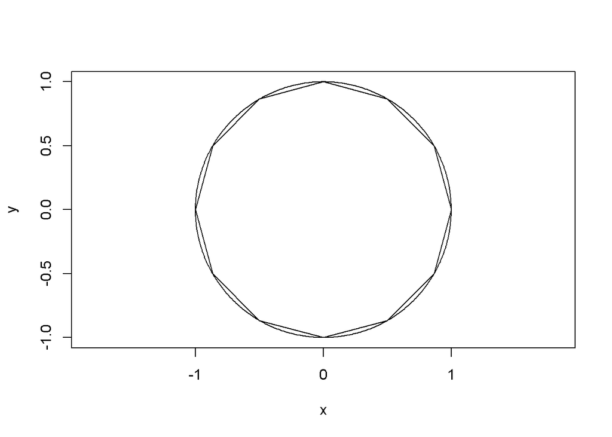

```r
plot(circle(n_vert = 12), type = "l", asp = 1)
lines(circle(n_vert = 720))
```

It should be clear that we can play this game forever, and the mathematician can just say, “nah it’s not a circle”. (They will also quibble about “forever”. . . .)

What about the centre of this circle? We know where that is, by definition. Right?

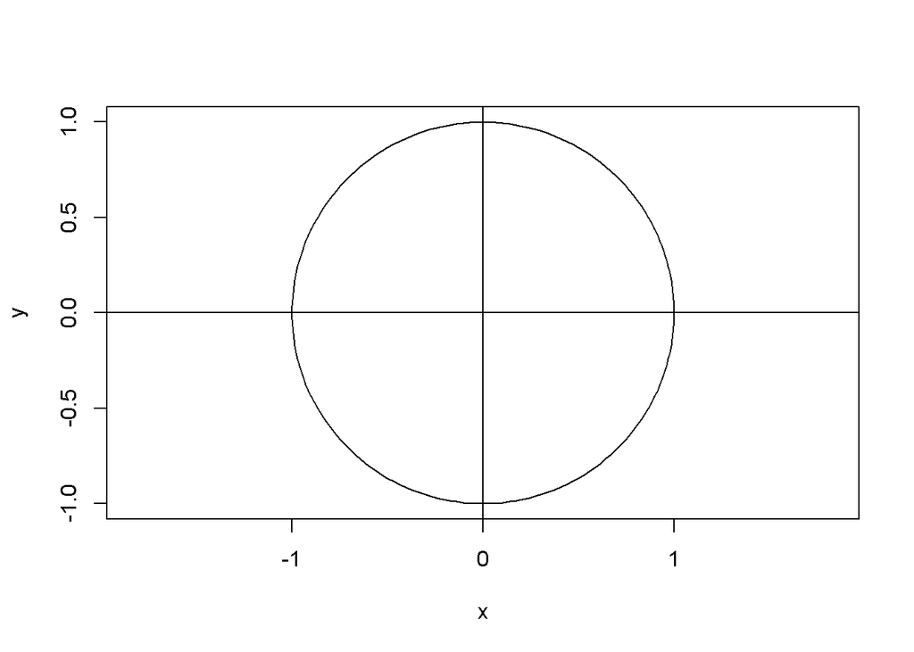

```r
plot(circle(), type = "l", asp = 1)
abline(v = 0, h = 0)
```

It doesn’t matter how we represent the circle, that point is always its centre. QED.

What does “centre” mean?

## Centroids ain’t centroids

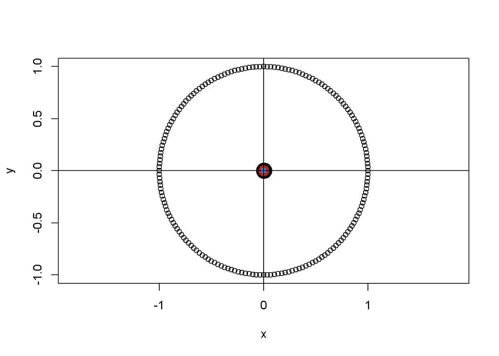

```r
## https://gist.github.com/mdsumner/52f8e6a674590e147ca7
#' @param x a 2-column matrix
centroid_weight <- function(x) {
  # centroid (weight)
  matrix(apply(x, 2, mean), ncol = 2)
}

library(tripack)
#' @param x a 2-column matrix
centroid_circle <- function(x) {
  ## minimum enclosing circle centre
  mec0 <- tripack::circumcircle(x[,1], x[,2])
  matrix(mec0[c("x", "y")], ncol = 2)
}

centroid_box <- function(x) {
  m <- expand.grid(x = range(x[,1]), y = range(x[,2]))
  ## box centroid
  matrix(apply(m, 2, mean), ncol = 2)
}

plot(circle(), asp = 1)
points(centroid_weight(circle()), pch = 19, cex = 3)
points(centroid_circle(circle()), pch = 19, cex = 2, col = "firebrick")
points(centroid_box(circle()), pch = 19, cex = 1, col = "dodgerblue")
abline(v = 0, h = 0)
```

They aren’t all the same, but can we tell?

```r
centroid_weight(circle())
```

```
##             [,1]          [,2]
## [1,] 0.005524862 -1.075424e-17
```

```r
centroid_circle(circle())
```

```
##      [,1]         [,2]
## [1,] 1.747486e-17 0
```

```r
centroid_box(circle())
```

```
##      [,1] [,2]
## [1,]    0    0
```

Only the “weight” method is *really* different, but we’d want to be careful with how we check all this.

We can make the weighted centroid *more correct*, but again we need to be careful because the *circle* method could take quite a bit of time, for no gain.

```r
centroid_weight(circle(n_vert = 720))
```

```
##             [,1]         [,2]
## [1,] 0.001386963 -2.60915e-18
```

```r
centroid_circle(circle(n_vert = 720))
```

```
##      [,1]         [,2]
## [1,] 2.018932e-17 0
```

```r
centroid_box(circle(n_vert = 720))
```

```
##      [,1] [,2]
## [1,]    0    0
```

It might be surprising how much we need to get closer to “near-zero”, but I think you’ll agree that this is *close enough*, at least for today. Neatly, we don’t even need much of a circle as input for the *circle* method to work, and be comparably fast.

```r
centroid_weight(circle(n_vert = 72000))
```

```
##             [,1]         [,2]
## [1,] 1.38887e-05 3.729796e-17
```

```r
centroid_circle(circle(n_vert = 6))
```

```
##      [,1] [,2]
## [1,] 0    6.123032e-17
```

```r
centroid_box(circle(n_vert = 72000))
```

```
##      [,1] [,2]
## [1,]    0    0
```

This is a lot to think about and we’ve only looked at three definitions of “centroid”. We need tonnes of points to get near to the correct centre with the weight method, but don’t try giving lots of points to the circle method if you want the centre of a circle, and box really doesn’t care it’s going to be fast and give the same answer no matter.

## Where is the centre of Australia?

This is easy, it’s Hobart! Where is it really?

```r
## no, I don't want to go into details about whether this map is "correct"
library(rworldmap)
data(countriesLow)

aus <- subset(countriesLow, SOVEREIGNT == "Australia")
```

What does GEOS 3.5.0 say?

```r
rgeos::gCentroid(aus)
```

```
## SpatialPoints:
##          x         y
## 1 134.4857 -25.73486
## Coordinate Reference System (CRS) arguments: +proj=longlat
## +ellps=WGS84 +datum=WGS84 +no_defs
```

What about `sf` with its GEOS 3.5.0?

```r
sf::st_centroid(sf::st_union(sf::st_as_sf(aus)))
```

```
## Geometry set for 1 feature
## geometry type:  POINT
## dimension:      XY
## bbox:           xmin: 134.4857 ymin: -25.73486 xmax: 134.4857 ymax: -25.73486
## epsg (SRID):    NA
## proj4string:    NA
```

```
## POINT(134.485734620193 -25.7348608583544)
```